# Spatial Data and Mapping

Author

Tucker Plumlee and Paul Liu

Published

Wednesday, June 3, 2026; 2:30PM

## 1 Getting Geographic Data from tidycensus and tigris

### 1.1 The `geometry` Argument in tidycensus

In a previous session, we used `get_acs()` from tidycensus to pull population data for Oregon counties. One of the arguments we used was `geometry = TRUE`. This is the key to unlocking mapping in R with Census data.

When you set `geometry = TRUE`, tidycensus does not just return a table of numbers — it also downloads the **TIGER/Line shapefiles** from the U.S. Census Bureau and attaches them to your data. TIGER/Line files are the official geographic boundary files the Census Bureau uses to define the shapes of states, counties, tracts, and other geographies. The result is an `sf` (simple features) object: a data frame where one column (`geometry`) contains the spatial information for each row.

This means you get your data and your map boundaries in a single, tidy object — ready to plot or analyze without any additional file downloads.

### 1.2 The tigris Package

Behind the scenes, tidycensus uses the tigris package to download shapefiles. You can also use tigris directly when you need geographic boundaries without Census data attached. For example:

```r
library(tigris)

# Download Oregon county boundaries
or_counties_geo <- counties(state = "OR", year = 2024)

# Download Oregon state boundary
or_state <- states() |> filter(STUSPS == "OR")

# Download roads for a specific county
or_roads <- roads(state = "OR", county = "Multnomah", year = 2024)
```

The tigris package provides functions for many geography types: `states()`, `counties()`, `tracts()`, `block_groups()`, `places()`, `roads()`, `school_districts()`, and more.

### 1.3 Loading Our Data

In the previous session, we pulled ACS data for Oregon counties with `geometry = TRUE` and saved it. Let’s load that data now:

```r
or_geo_data <- readRDS("Data/or_geo_data.RDS")

# Take a look at the structure
glimpse(or_geo_data)
```

```
Rows: 36
Columns: 8
$ GEOID      <chr> "41015", "41007", "41035", "41033", "41065", "41017", "4103…
$ NAME       <chr> "Curry County, Oregon", "Clatsop County, Oregon", "Klamath …
$ pop_2024   <dbl> 23381, 41363, 70247, 88179, 26552, 206334, 25203, 1938, 801…
$ pop_2019   <dbl> 22650, 39102, 66921, 86251, 26130, 186251, 23607, 1642, 804…
$ geometry   <MULTIPOLYGON [°]> MULTIPOLYGON (((-124.3239 4..., MULTIPOLYGON (…
$ pop_change <dbl> 731, 2261, 3326, 1928, 422, 20083, 1596, 296, -3129, 93, 15…
$ pct_change <dbl> 3.2273731, 5.7823129, 4.9700393, 2.2353364, 1.6150019, 10.7…
$ county     <chr> "Curry", "Clatsop", "Klamath", "Josephine", "Wasco", "Desch…
```

Notice the `geometry` column — it contains the polygon shapes for each county. The `sf` package knows how to work with this column, and ggplot2 and tmap both understand `sf` objects natively.

```r
class(or_geo_data)
```

```
[1] "sf"         "data.frame"
```

The object has both `sf` and `data.frame` classes, which means it works with all your familiar dplyr operations *and* spatial functions.

## 2 Mapping in ggplot2 and tmap

### 2.1 Basic Choropleth Maps Using ggplot2

A **choropleth map** colors geographic areas based on a data variable. With ggplot2, creating one from an `sf` object is straightforward using `geom_sf()`:

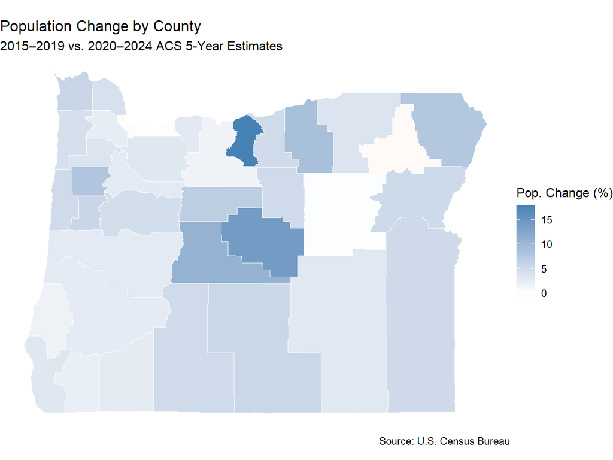

Figure 1: Percentage Population Change by Oregon County

```r
ggplot(or_geo_data) +
  geom_sf(aes(fill = pct_change), color = "white", linewidth = 0.2) +
  scale_fill_gradient2(
    low = "tomato",
    mid = "white",
    high = "steelblue",
    midpoint = 0,
    name = "Pop. Change (%)"
  ) +
  labs(
    title = "Population Change by County",
    subtitle = "2015–2019 vs. 2020–2024 ACS 5-Year Estimates",
    caption = "Source: U.S. Census Bureau"
  ) +
  theme_void(base_size = 12) +
  theme(
    legend.position = "right"
  )
```

`geom_sf()` automatically handles the projection and geometry — you just map aesthetics like `fill` to your data variable the same way you would in any other ggplot. `theme_void()` removes axes, gridlines, and background, which is standard for maps.

You can also add labels:

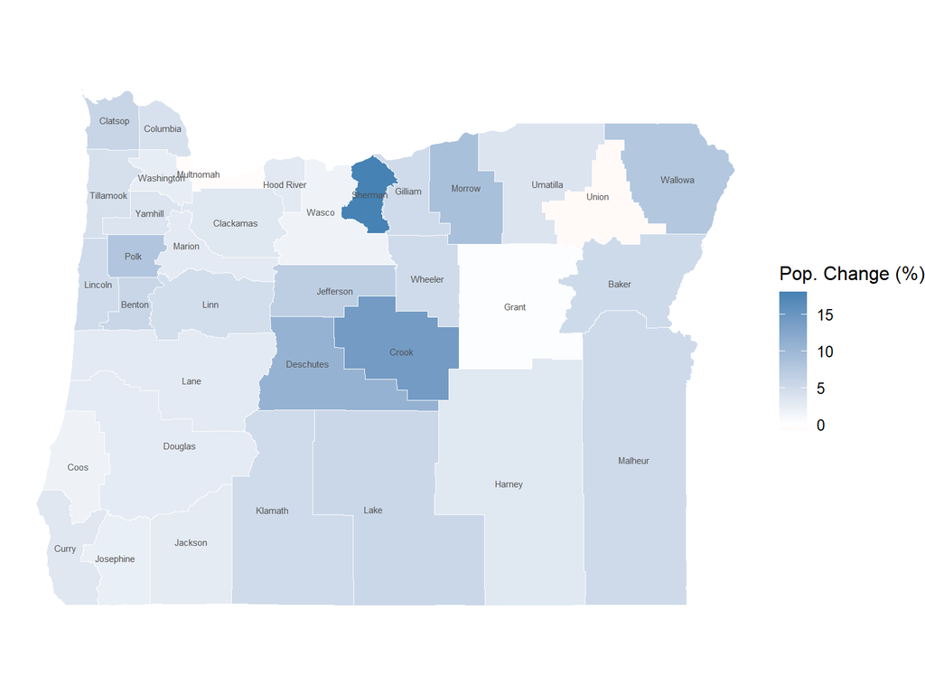

Figure 2: Oregon Counties with Labels

```r
ggplot(or_geo_data) +
  geom_sf(aes(fill = pct_change), color = "white", linewidth = 0.2) +
  geom_sf_text(aes(label = county), size = 2, color = "grey30") +
  scale_fill_gradient2(
    low = "tomato", mid = "white", high = "steelblue",
    midpoint = 0, name = "Pop. Change (%)"
  ) +
  theme_void(base_size = 12)
```

**Exercise 1: ggplot2 Choropleth**

Create a choropleth map of Oregon counties showing **2024 population** (`pop_2024`) instead of population change. Use a sequential color scale (`scale_fill_viridis_c()` is a good option). Add a title and source caption.

```r
ggplot(or_geo_data) +
  geom_sf(aes(fill = ______), color = "white", linewidth = 0.2) +
  scale_fill_viridis_c(name = "Population") +
  labs(
    title = "______",
    caption = "Source: U.S. Census Bureau"
  ) +
  theme_void()
```

### 2.2 Using tmap for Additional Customization

While ggplot2 handles basic maps well, the [tmap](https://r-tmap.github.io/tmap/) package is purpose-built for thematic mapping and offers **greater control over choropleth scales** — the classification methods used to bin continuous data into color categories. This matters because different binning methods can tell very different stories with the same data.

#### 2.2.1 Quick Look with `qtm()`

The `qtm()` function (short for “quick thematic map”) is tmap’s equivalent of ggplot2’s `qplot()` — a fast way to get a map on screen:

```
[scale] tm_polygons:() the data variable assigned to 'fill' contains positive and negative values, so midpoint is set to 0. Set 'midpoint = NA' in 'fill.scale = tm_scale_intervals(<HERE>)' to use all visual values (e.g. colors)
```

```
[scale] tm_symbols:() the data variable assigned to 'fill' contains positive and negative values, so midpoint is set to 0. Set 'midpoint = NA' in 'fill.scale = tm_scale_intervals(<HERE>)' to use all visual values (e.g. colors)
```

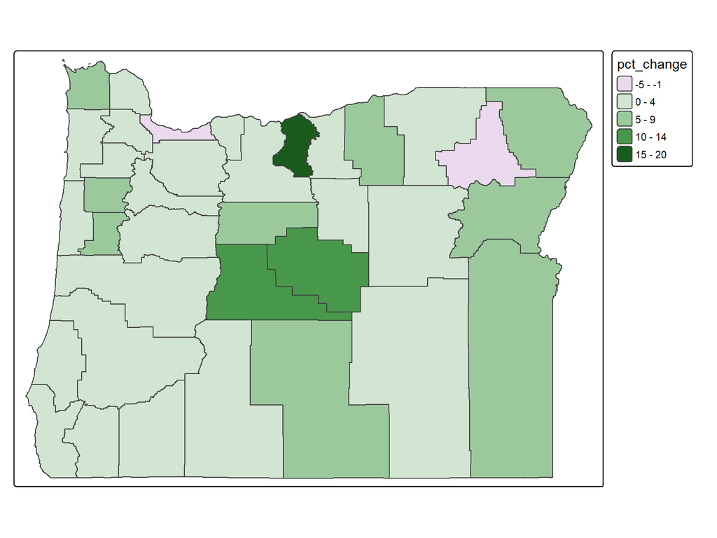

Figure 3: Quick Thematic Map of Population Change

```r
qtm(or_geo_data, fill = "pct_change")
```

With a single line, tmap creates a choropleth with a legend and sensible defaults. This is useful for quick exploration before building a more polished map.

#### 2.2.2 Building a Map with `tm_shape()` and `tm_polygons()`

For more control, use the layered tmap syntax. This starts with `tm_shape()` (which specifies the data) followed by layer functions like `tm_polygons()`:

```
[scale] tm_polygons:() the data variable assigned to 'fill' contains positive and negative values, so midpoint is set to 0. Set 'midpoint = NA' in 'fill.scale = tm_scale_intervals(<HERE>)' to use all visual values (e.g. colors)
```

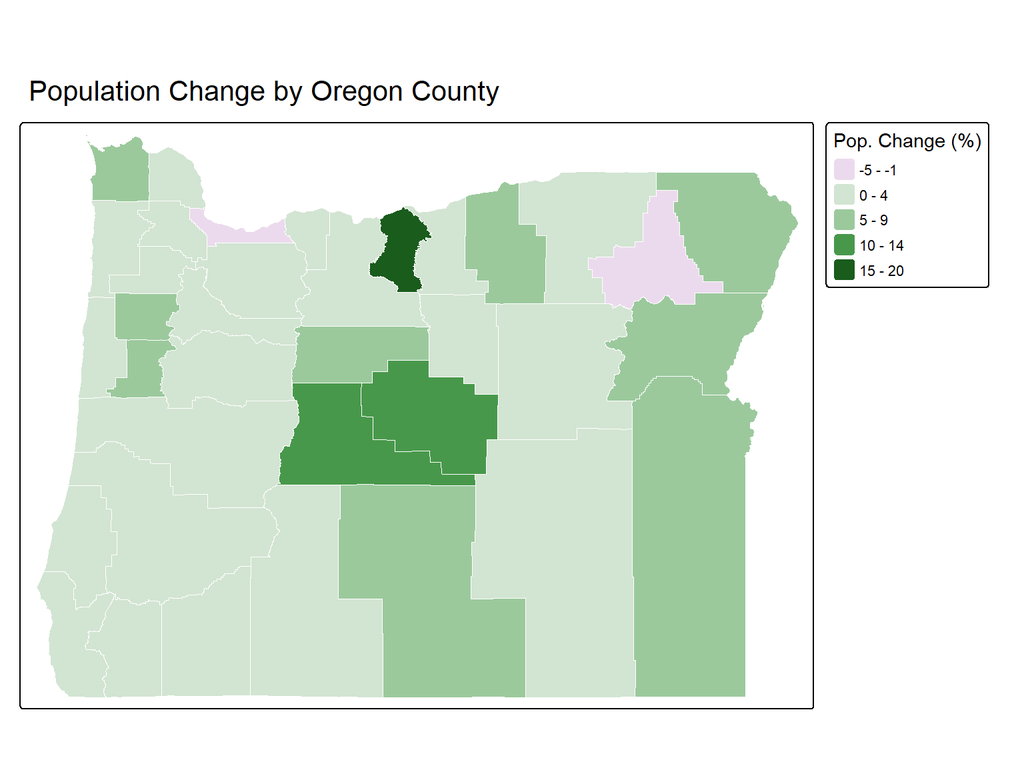

Figure 4: Population Change with tmap Default Intervals

```r
tm_shape(or_geo_data) +
  tm_polygons(
    fill = "pct_change",
    fill.legend = tm_legend(title = "Pop. Change (%)"),
    col = "white",
    lwd = 0.5
  ) +
  tm_title("Population Change by Oregon County")
```

#### 2.2.3 Trying Different Scales

The real power of tmap is in its scale system. The `fill.scale` argument inside `tm_polygons()` lets you control exactly how numeric values are mapped to colors. The `tm_scale_intervals()` function offers many classification styles:

- **`"pretty"`** — rounds to nice break values (default)
- **`"equal"`** — divides the range into equal-width intervals
- **`"quantile"`** — each class has roughly the same number of observations
- **`"jenks"`** — minimizes within-class variance (natural breaks)
- **`"fisher"`** — similar to Jenks, optimized for speed
- **`"sd"`** — intervals based on standard deviations from the mean

Let’s compare a few:

```
[scale] tm_polygons:() the data variable assigned to 'fill' contains positive and negative values, so midpoint is set to 0. Set 'midpoint = NA' in 'fill.scale = tm_scale_intervals(<HERE>)' to use all visual values (e.g. colors)
```

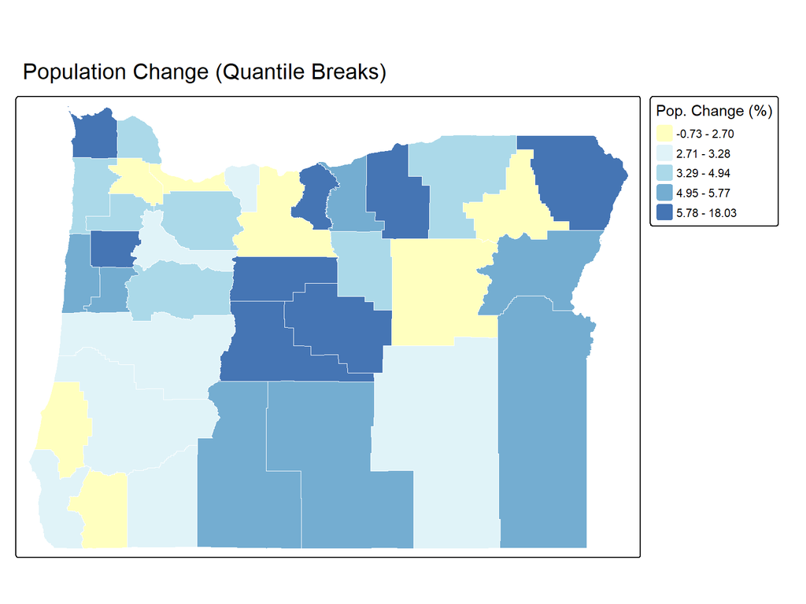

Figure 5: Quantile Classification (Equal Count per Class)

```r
tm_shape(or_geo_data) +
  tm_polygons(
    fill = "pct_change",
    fill.scale = tm_scale_intervals(
      style = "quantile",
      n = 5,
      values = "brewer.rd_yl_bu"
    ),
    fill.legend = tm_legend(title = "Pop. Change (%)"),
    col = "white",
    lwd = 0.5
  ) +
  tm_title("Population Change (Quantile Breaks)")
```

```
[scale] tm_polygons:() the data variable assigned to 'fill' contains positive and negative values, so midpoint is set to 0. Set 'midpoint = NA' in 'fill.scale = tm_scale_intervals(<HERE>)' to use all visual values (e.g. colors)
```

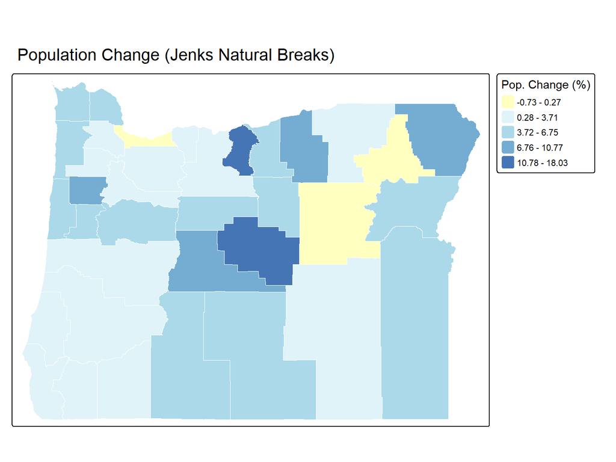

Figure 6: Jenks Natural Breaks Classification

```r
tm_shape(or_geo_data) +
  tm_polygons(
    fill = "pct_change",
    fill.scale = tm_scale_intervals(
      style = "jenks",
      n = 5,
      values = "brewer.rd_yl_bu"
    ),
    fill.legend = tm_legend(title = "Pop. Change (%)"),
    col = "white",
    lwd = 0.5
  ) +
  tm_title("Population Change (Jenks Natural Breaks)")
```

You can also use a continuous scale instead of intervals:

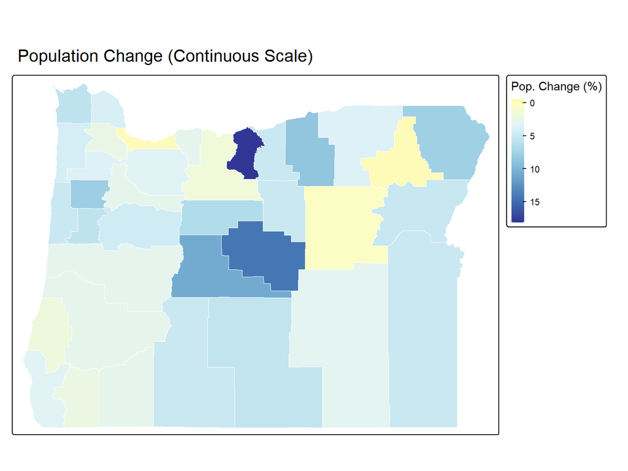

Figure 7: Continuous Color Scale

```r
tm_shape(or_geo_data) +
  tm_polygons(
    fill = "pct_change",
    fill.scale = tm_scale_continuous(
      midpoint = 0,
      values = "brewer.rd_yl_bu"
    ),
    fill.legend = tm_legend(title = "Pop. Change (%)"),
    col = "white",
    lwd = 0.5
  ) +
  tm_title("Population Change (Continuous Scale)")
```

**Classification Choices Matter**

The same data mapped with different classification methods can lead to very different visual impressions. Quantile breaks ensure even color distribution but can group very different values together. Jenks breaks highlight natural clusters but may have uneven class sizes. Always consider your audience and the story you want to tell when choosing a classification method.

#### 2.2.4 Basic Interactive Map

One of tmap’s standout features is the ability to switch between static (“plot”) and interactive (“view”) modes. Interactive maps use Leaflet under the hood and let users zoom, pan, and click on features:

```r
# Switch to interactive mode
tmap_mode("view")
```

```
ℹ tmap modes "plot" - "view"
ℹ toggle with `tmap::ttm()`
```

```r
tm_shape(or_geo_data) +
  tm_polygons(
    fill = "pct_change",
    fill.scale = tm_scale_intervals(
      style = "jenks",
      n = 5,
      values = "brewer.rd_yl_bu"
    ),
    fill.legend = tm_legend(title = "Pop. Change (%)"),
    col = "white",
    lwd = 0.5
  )
```

```
[scale] tm_polygons:() the data variable assigned to 'fill' contains positive and negative values, so midpoint is set to 0. Set 'midpoint = NA' in 'fill.scale = tm_scale_intervals(<HERE>)' to use all visual values (e.g. colors)
```

[interactive chart not shown]

Figure 8: Interactive Map of Population Change

Click on any county in the interactive map to see its data values. This is especially useful for presentations and exploratory analysis.

**Exercise 2: tmap Scale Comparison**

Create two side-by-side maps of the `pop_2024` variable (total 2024 population): one using `style = "equal"` and one using `style = "quantile"`, both with 5 classes. Use the `tmap_arrange()` function to display them together. How do the two maps differ in what they emphasize?

```r
map_equal <- tm_shape(or_geo_data) +
  tm_polygons(
    fill = "pop_2024",
    fill.scale = tm_scale_intervals(style = "______", n = 5),
    fill.legend = tm_legend(title = "Population")
  ) +
  tm_title("Equal Intervals")

map_quantile <- tm_shape(or_geo_data) +
  tm_polygons(
    fill = "pop_2024",
    fill.scale = tm_scale_intervals(style = "______", n = 5),
    fill.legend = tm_legend(title = "Population")
  ) +
  tm_title("Quantile Breaks")

tmap_arrange(map_equal, map_quantile)
```

## 3 Basic GIS Using sf

### 3.1 GIS Fundamentals

**GIS** (Geographic Information Systems) is the practice of analyzing spatial data — data that has a geographic location associated with it. The core GIS operations we will cover today involve:

- **Dissolving/merging** geometries: combining multiple smaller areas into larger regions
- **Aggregating** data during a dissolve: summing or averaging values for the merged areas
- **Reading shapefiles**: loading external geographic data files
- **Spatial joins**: linking datasets based on geographic overlap rather than shared keys

In R, the `sf` (simple features) package provides all of these capabilities. Because `sf` objects are also data frames, you can use familiar dplyr functions like `group_by()`, `summarize()`, and `left_join()` — and sf will handle the geometry automatically.

### 3.2 Merging Counties into Workforce Investment Board (WIB) Regions

Oregon’s counties are grouped into **Workforce Investment Board (WIB)** regions. Let’s dissolve individual county shapes into WIB regions and recalculate population statistics for each.

#### 3.2.1 Step 1: Load and Prepare the Crosswalk

First, we will load a crosswalk table that maps each county to its WIB region, then join it to our geographic data:

```r
# Load the county-to-WIB crosswalk
wib_crosswalk <- read_csv("Data/OR_WIB_Counties.csv")
head(wib_crosswalk)
```

```
# A tibble: 6 × 8
  OBJECTID_1 OBJECTID COUNTY_NAM CNTY_CODE Region    Shape_Leng  Shape__Area
       <dbl>    <dbl> <chr>      <chr>     <chr>          <dbl>        <dbl>
1          1        1 CLATSOP    007       Northwest    780230.  5817006151.
2          2        2 COLUMBIA   009       Northwest    586399.  3689521189.
3          3        3 WALLOWA    063       Eastern     1382113. 16662081017.
4          4        4 UMATILLA   059       Eastern     1577337. 17090820245.
5          5        5 MORROW     049       Eastern     1109805. 10763814277.
6          6        6 UNION      061       Eastern     1547829. 10676404230.
# ℹ 1 more variable: Shape__Length <dbl>
```

The crosswalk has a `CNTY_CODE` field, but our geographic data uses a full `GEOID` that includes the state FIPS code. Oregon’s state FIPS code is **41**, so we need to prepend it:

```r
# Create a GEOID field by adding "41" to the front of CNTY_CODE
wib_crosswalk <- wib_crosswalk |>
  mutate(GEOID = paste0("41", CNTY_CODE))

head(wib_crosswalk)
```

```
# A tibble: 6 × 9
  OBJECTID_1 OBJECTID COUNTY_NAM CNTY_CODE Region    Shape_Leng  Shape__Area
       <dbl>    <dbl> <chr>      <chr>     <chr>          <dbl>        <dbl>
1          1        1 CLATSOP    007       Northwest    780230.  5817006151.
2          2        2 COLUMBIA   009       Northwest    586399.  3689521189.
3          3        3 WALLOWA    063       Eastern     1382113. 16662081017.
4          4        4 UMATILLA   059       Eastern     1577337. 17090820245.
5          5        5 MORROW     049       Eastern     1109805. 10763814277.
6          6        6 UNION      061       Eastern     1547829. 10676404230.
# ℹ 2 more variables: Shape__Length <dbl>, GEOID <chr>
```

Now join the crosswalk to the geographic data:

```r
# Join the WIB region assignment to the county data
or_geo_wib <- or_geo_data |>
  left_join(wib_crosswalk, by = "GEOID")

head(or_geo_wib)
```

```
Simple feature collection with 6 features and 15 fields
Geometry type: MULTIPOLYGON
Dimension:     XY
Bounding box:  xmin: -124.5662 ymin: 41.99302 xmax: -119.8966 ymax: 46.29083
Geodetic CRS:  NAD83
  GEOID                     NAME pop_2024 pop_2019 pop_change pct_change
1 41015     Curry County, Oregon    23381    22650        731   3.227373
2 41007   Clatsop County, Oregon    41363    39102       2261   5.782313
3 41035   Klamath County, Oregon    70247    66921       3326   4.970039
4 41033 Josephine County, Oregon    88179    86251       1928   2.235336
5 41065     Wasco County, Oregon    26552    26130        422   1.615002
6 41017 Deschutes County, Oregon   206334   186251      20083  10.782761
     county OBJECTID_1 OBJECTID COUNTY_NAM CNTY_CODE          Region Shape_Leng
1     Curry         34       34      CURRY       015     South Coast  1435017.7
2   Clatsop          1        1    CLATSOP       007       Northwest   780230.3
3   Klamath         32       32    KLAMATH       035         Central  2035402.6
4 Josephine         36       36  JOSEPHINE       033 Southern Oregon  1082509.0
5     Wasco         13       13      WASCO       065         Central  1610949.4
6 Deschutes         27       27  DESCHUTES       017         Central  1743721.7
  Shape__Area Shape__Length                       geometry
1  9497691745      593357.7 MULTIPOLYGON (((-124.3239 4...
2  5817006151      342372.7 MULTIPOLYGON (((-123.6647 4...
3 29436592641      845444.2 MULTIPOLYGON (((-122.29 42....
4  7789808770      446827.1 MULTIPOLYGON (((-124.042 42...
5 12479511451      696437.2 MULTIPOLYGON (((-121.8053 4...
6 15252206223      737298.7 MULTIPOLYGON (((-122.0019 4...
```

#### 3.2.2 Step 2: Dissolve County Shapes into WIB Regions

Here is where the GIS magic happens. When you `group_by()` and `summarize()` an `sf` object, sf automatically **dissolves** (merges) the geometries of grouped features. At the same time, you can aggregate your data variables:

```r
# Dissolve counties into WIB regions and aggregate population
or_wib <- or_geo_wib |>
  group_by(Region) |>
  summarize(
    pop_2024 = sum(pop_2024, na.rm = TRUE),
    pop_2019 = sum(pop_2019, na.rm = TRUE),
    .groups = "drop"
  )

or_wib
```

```
Simple feature collection with 9 features and 3 fields
Geometry type: GEOMETRY
Dimension:     XY
Bounding box:  xmin: -124.5662 ymin: 41.99179 xmax: -116.4635 ymax: 46.29083
Geodetic CRS:  NAD83
# A tibble: 9 × 4
  Region          pop_2024 pop_2019                                     geometry
  <chr>              <dbl>    <dbl>                               <GEOMETRY [°]>
1 Central           392179   361901 POLYGON ((-121.8057 45.00612, -121.8044 45.…
2 Clackamas         423975   410463 POLYGON ((-122.8681 45.2597, -122.8499 45.2…
3 Eastern           189439   182660 POLYGON ((-119.9438 42.74637, -119.706 42.7…
4 Lane              384207   373340 POLYGON ((-124.1587 43.86372, -124.1388 43.…
5 Mid-Valley        678346   652557 POLYGON ((-123.2607 44.55636, -123.2602 44.…
6 Northwest         269619   256520 MULTIPOLYGON (((-123.6026 44.72115, -123.70…
7 Portland Metro   1405424  1394087 POLYGON ((-123.4861 45.4332, -123.4649 45.4…
8 South Coast       200280   195450 MULTIPOLYGON (((-124.219 43.61093, -124.232…
9 Southern Oregon   310824   302825 POLYGON ((-123.2296 42.70261, -123.2492 42.…
```

Each row now represents a WIB region instead of a county. The `geometry` column contains the merged polygon — sf combined the county boundaries within each region into a single shape.

#### 3.2.3 Step 3: Recalculate Population Change

Since we aggregated the raw population counts, we need to recalculate the percentage change for each WIB region:

```r
or_wib <- or_wib |>
  mutate(
    pop_change = pop_2024 - pop_2019,
    pct_change = (pop_change / pop_2019) * 100
  )

or_wib
```

```
Simple feature collection with 9 features and 5 fields
Geometry type: GEOMETRY
Dimension:     XY
Bounding box:  xmin: -124.5662 ymin: 41.99179 xmax: -116.4635 ymax: 46.29083
Geodetic CRS:  NAD83
# A tibble: 9 × 6
  Region       pop_2024 pop_2019                  geometry pop_change pct_change
* <chr>           <dbl>    <dbl>            <GEOMETRY [°]>      <dbl>      <dbl>
1 Central        392179   361901 POLYGON ((-121.8057 45.0…      30278      8.37
2 Clackamas      423975   410463 POLYGON ((-122.8681 45.2…      13512      3.29
3 Eastern        189439   182660 POLYGON ((-119.9438 42.7…       6779      3.71
4 Lane           384207   373340 POLYGON ((-124.1587 43.8…      10867      2.91
5 Mid-Valley     678346   652557 POLYGON ((-123.2607 44.5…      25789      3.95
6 Northwest      269619   256520 MULTIPOLYGON (((-123.602…      13099      5.11
7 Portland Me…  1405424  1394087 POLYGON ((-123.4861 45.4…      11337      0.813
8 South Coast    200280   195450 MULTIPOLYGON (((-124.219…       4830      2.47
9 Southern Or…   310824   302825 POLYGON ((-123.2296 42.7…       7999      2.64
```

#### 3.2.4 Step 4: Map Population Change by WIB Region

Now let’s map the WIB regions just as we mapped counties earlier:

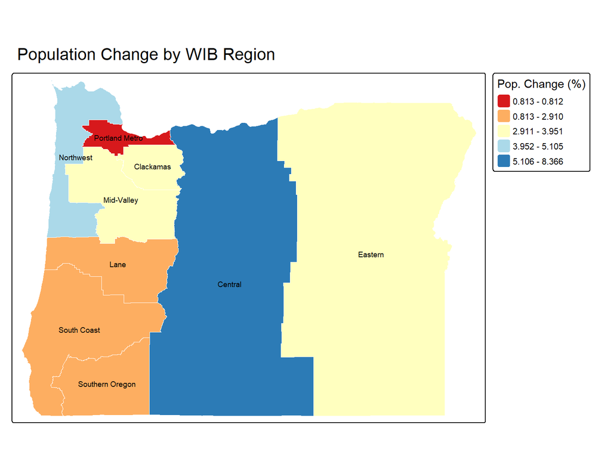

Figure 9: Percentage Population Change by WIB Region

```r
tm_shape(or_wib) +
  tm_polygons(
    fill = "pct_change",
    fill.scale = tm_scale_intervals(
      style = "jenks",
      values = "brewer.rd_yl_bu"
    ),
    fill.legend = tm_legend(title = "Pop. Change (%)"),
    col = "white",
    lwd = 0.5
  ) +
  tm_text("Region", size = 0.6) +
  tm_title("Population Change by WIB Region")
```

Compare this map with the county-level version. Aggregating to WIB regions smooths out county-level variation and highlights broader regional trends.

**Exercise 3: Dissolve Practice**

Using the `or_geo_wib` dataset (which has both county data and WIB assignments), dissolve the counties into WIB regions but this time calculate the **mean** unemployment rate (if the data includes one) or the **total** `pop_2024` and the **number of counties** in each region. Map the number of counties per WIB to see which regions cover the most counties.

```r
or_wib_counts <- or_geo_wib |>
  group_by(______) |>
  summarize(
    n_counties = n(),
    total_pop = sum(______, na.rm = TRUE),
    .groups = "drop"
  )

tm_shape(or_wib_counts) +
  tm_polygons(
    fill = "n_counties",
    fill.legend = tm_legend(title = "# Counties")
  ) +
  tm_text("Region", size = 0.6)
```

### 3.3 Loading Shapefiles

Not all geographic data comes from tidycensus. You will often work with shapefiles (`.shp` files) from state agencies, federal programs, or other sources. The `sf` package reads shapefiles with `st_read()`.

#### 3.3.1 Reading a WIB Region Shapefile

Let’s read in a WIB shapefile provided by Oregon:

```r
# Read the WIB shapefile
or_wib_shp <- st_read("Data/OR_WIB/OR_WIB.shp")
# Look at the structure
glimpse(or_wib_shp)
```

```
Rows: 9
Columns: 2
$ Region   <chr> "Central", "Clackamas", "Eastern", "Lane", "Mid-Valley", "Nor…
$ geometry <POLYGON [m]> POLYGON ((-13346795 5404873..., POLYGON ((-13650687 5…
```

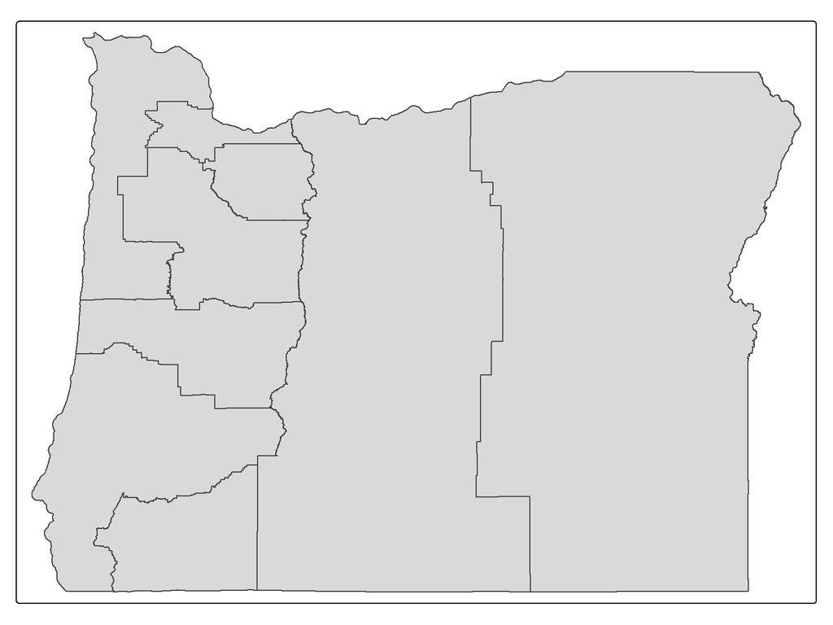

Figure 10: WIB Regions from Shapefile

```r
qtm(or_wib_shp)
```

**Shapefile Components**

A “shapefile” is actually a collection of files that work together. At minimum you will see `.shp` (geometry), `.shx` (spatial index), `.dbf` (attributes), and `.prj` (projection). When you point `st_read()` at the `.shp` file, it automatically finds and reads the companion files. Always keep all the component files together in the same folder.

#### 3.3.2 Reading a Point Shapefile

Shapefiles can represent points (like locations), lines (like roads), or polygons (like boundaries). Let’s read in a point shapefile of Oregon community colleges:

```r
# Read the community college locations
or_colleges <- st_read("Data/OR_Colleges/OR_Colleges.shp")
glimpse(or_colleges)
```

```
Rows: 17
Columns: 6
$ NAME     <chr> "Blue Mountain Community College", "Central Oregon Community …
$ ADDRESS  <chr> "2411 Northwest Carden Avenue", "2600 Northwest College Way",…
$ CITY     <chr> "Pendleton", "Bend", "Salem", "Oregon City", "Astoria", "The …
$ STATE    <chr> "OR", "OR", "OR", "OR", "OR", "OR", "OR", "OR", "OR", "OR", "…
$ ZIPCODE  <chr> "97801", "97703", "97305", "97045", "97103", "97058", "97603"…
$ geometry <POINT [m]> POINT (-13226562 5728685), POINT (-13508299 5475915), P…
```

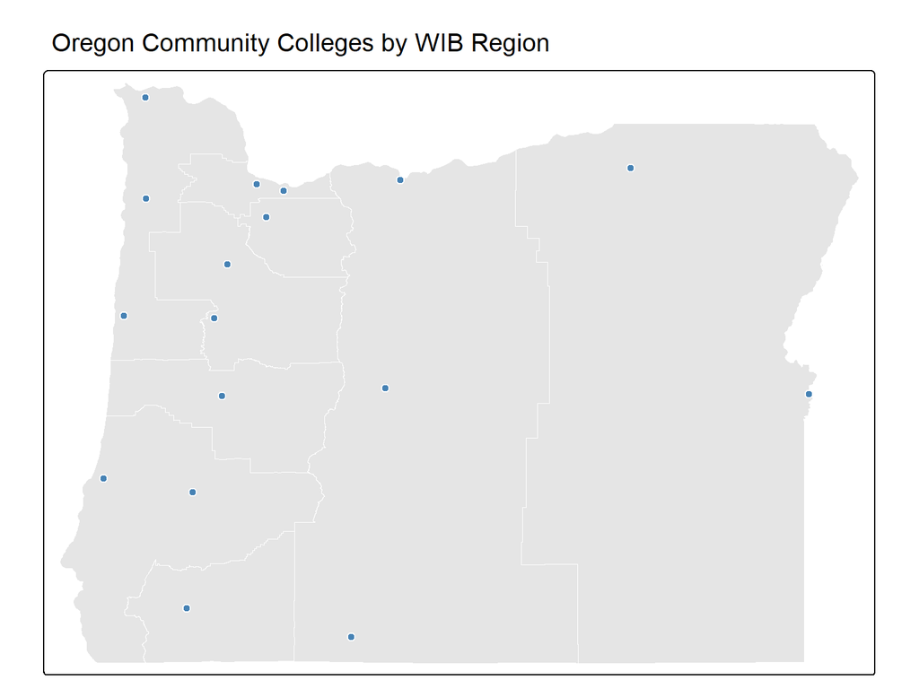

Figure 11: Oregon Community Colleges Overlaid on WIB Regions

```r
tm_shape(or_wib_shp) +
  tm_polygons(fill = "grey90", col = "white", lwd = 0.5) +
tm_shape(or_colleges) +
  tm_symbols(size = 0.5, fill = "steelblue", col = "white") +
  tm_title("Oregon Community Colleges by WIB Region")
```

tmap builds maps in layers, just like ggplot2. Here we add the WIB region polygons first as a base layer, then overlay the college point locations on top.

**Exercise 4: Layer Multiple Datasets**

Create a map that shows the dissolved WIB regions (from `or_wib`, the dataset we created by dissolving counties) with population change as the fill color, then overlay the community college points on top. This combines the choropleth we built earlier with the point layer.

```r
tm_shape(______) +
  tm_polygons(
    fill = "pct_change",
    fill.scale = tm_scale_intervals(style = "jenks", values = "brewer.rd_yl_bu"),
    fill.legend = tm_legend(title = "Pop. Change (%)")
  ) +
tm_shape(______) +
  tm_symbols(size = 0.5, fill = "black") +
  tm_title("Community Colleges and WIB Population Change")
```

### 3.4 Spatial Joins

A **spatial join** links two datasets based on geographic relationship (like intersection or containment) rather than a shared key column. This is one of the most useful GIS operations: if you have points (colleges) and polygons (WIB regions), a spatial join tells you which polygon each point falls inside.

#### 3.4.1 Joining Colleges to WIB Regions

Let’s associate each community college with the WIB region it is located in, along with that region’s population change data. We use `st_join()` from the sf package:

```r
# First, make sure both datasets use the same coordinate reference system
or_colleges_proj <- st_transform(or_colleges, st_crs(or_wib))

# Spatial join: for each college, find which WIB region it falls in
colleges_with_wib <- st_join(or_colleges_proj, or_wib)

# View the result
colleges_with_wib |>
  st_drop_geometry() |>
  head(10)
```

```
                                          NAME                          ADDRESS
1              Blue Mountain Community College     2411 Northwest Carden Avenue
2             Central Oregon Community College       2600 Northwest College Way
3                  Chemeketa Community College   4000 Lancaster Drive Northeast
4                  Clackamas Community College       19600 South Molalla Avenue
5                    Clatsop Community College            1651 Lexington Avenue
6             Columbia Gorge Community College            400 East Scenic Drive
7                    Klamath Community College            7390 South 6th Street
8           Lane Community College Main Campus            4000 East 30th Avenue
9              Linn - Benton Community College 6500 Pacific Boulevard Southwest
10 Mount Hood Community College Gresham Campus     26000 Southeast Stark Street
            CITY STATE ZIPCODE         Region pop_2024 pop_2019 pop_change
1      Pendleton    OR   97801        Eastern   189439   182660       6779
2           Bend    OR   97703        Central   392179   361901      30278
3          Salem    OR   97305     Mid-Valley   678346   652557      25789
```

[output cut: 18 more lines]

Each college record now includes the `Region`, `pop_2024`, `pop_2019`, and `pct_change` fields from whichever WIB region it falls within. We did not need a shared ID column — the join was based purely on whether the college’s point geometry intersects the WIB region’s polygon geometry.

**Coordinate Reference Systems**

Spatial joins require both datasets to use the same **CRS** (Coordinate Reference System). The `st_transform()` function re-projects one dataset to match the other. If you forget this step, `st_join()` may produce incorrect results or throw an error. You can check a dataset’s CRS with `st_crs()`.

You can now use this joined data to answer questions like “which WIB region has the most community colleges?” or to map the colleges colored by their region’s population growth:

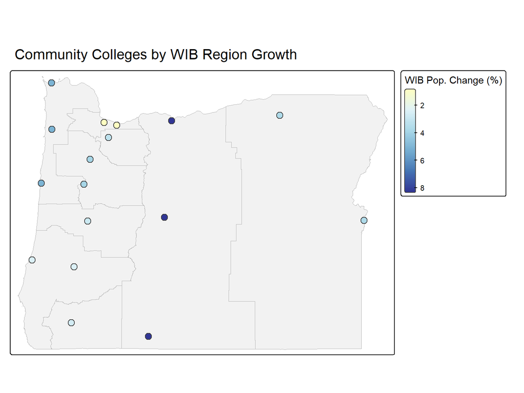

Figure 12: Oregon Community Colleges Colored by WIB Region Population Change

```r
tm_shape(or_wib) +
  tm_polygons(fill = "grey95", col = "grey70", lwd = 0.5) +
tm_shape(colleges_with_wib) +
  tm_symbols(
    fill = "pct_change",
    fill.scale = tm_scale_continuous(
      midpoint = 0,
      values = "brewer.rd_yl_bu"
    ),
    fill.legend = tm_legend(title = "WIB Pop. Change (%)"),
    size = 0.7
  ) +
  tm_title("Community Colleges by WIB Region Growth")
```

**Exercise 5: Spatial Join Exploration**

Using the `colleges_with_wib` data, count how many community colleges are in each WIB region. Which region has the most? Then create a bar chart (not a map) showing the count by region.

```r
colleges_with_wib |>
  st_drop_geometry() |>
  count(______) |>
  ggplot(aes(x = n, y = reorder(______, n))) +
  geom_col(fill = "steelblue") +
  labs(
    x = "Number of Community Colleges",
    y = NULL,
    title = "Community Colleges per WIB Region"
  ) +
  theme_minimal()
```

## 4 Wrapping Up

Today we covered the foundations of mapping and spatial analysis in R:

- **tidycensus and tigris** provide ready-to-map geographic data directly from the Census Bureau. Setting `geometry = TRUE` gives you shapefiles alongside your data.
- **ggplot2** handles basic choropleth maps with `geom_sf()`, using the same aesthetic mapping syntax you already know.
- **tmap** provides purpose-built thematic mapping with powerful scale controls, easy classification methods, and interactive maps with a single function call.
- **sf** enables GIS operations like dissolving geometries, reading shapefiles, and performing spatial joins — all integrated with the dplyr verbs you are already comfortable with.

These tools work together naturally: tidycensus and tigris bring in the data, sf handles spatial operations, and ggplot2 or tmap render the results.